# Comentários e cultura

```r
dados = read_csv(
    here::here("data/participation-per-country.csv"),
    col_types = cols(
        .default = col_double(),
        site = col_character(),
        country = col_character(),
        geo = col_character(),
        four_regions = col_character(),
        eight_regions = col_character(),
        six_regions = col_character(),
        `World bank income group 2017` = col_character()
    )
) %>%
    filter(usuarios > 200)
glimpse(dados)
```

```
## Observations: 121
## Variables: 21
## $ site                           <chr> "StackOverflow", "StackOverflow", "Sta…
## $ country                        <chr> "Argentina", "Australia", "Austria", "…
## $ PDI                            <dbl> 49, 36, 11, 80, 65, 69, 70, 39, 63, 80…
## $ IDV                            <dbl> 46, 90, 55, 20, 75, 38, 30, 80, 23, 20…
## $ MAS                            <dbl> 56, 61, 79, 55, 54, 49, 40, 52, 28, 66…
## $ UAI                            <dbl> 86, 51, 70, 60, 94, 76, 85, 48, 86, 30…
## $ usuarios                       <dbl> 2798, 12313, 2518, 2558, 4275, 10717, …
## $ responderam_prop               <dbl> 0.5357398, 0.6133355, 0.6310564, 0.392…
## $ perguntaram_prop               <dbl> 0.5210865, 0.5897832, 0.5933280, 0.475…
## $ editaram_prop                  <dbl> 0.09256612, 0.14699911, 0.14932486, 0.…
## $ comentaram_prop                <dbl> 0.25339528, 0.33395598, 0.35027800, 0.…
## $ GNI                            <dbl> NA, 59570, 48160, 840, 44990, 11630, 6…
## $ Internet                       <dbl> 51.0, 79.5, 79.8, 5.0, 78.0, 45.0, 51.…
## $ EPI                            <dbl> 59.02, NA, 63.21, NA, 61.21, 49.96, NA…
## $ geo                            <chr> "arg", "aus", "aut", "bgd", "bel", "br…
## $ four_regions                   <chr> "americas", "asia", "europe", "asia", …
## $ eight_regions                  <chr> "america_south", "east_asia_pacific", …
## $ six_regions                    <chr> "america", "east_asia_pacific", "europ…
## $ Latitude                       <dbl> -34.00000, -25.00000, 47.33333, 24.000…
## $ Longitude                      <dbl> -64.00000, 135.00000, 13.33333, 90.000…
## $ `World bank income group 2017` <chr> "Upper middle income", "High income", …
```

Estamos interessados na relação entre quanto as pessoas de diferentes países comentam em questões dos outros. A proporção das pessoas do país que comentou nas questões de outros está medido na variável `comentaram_prop`.

Considerando essa variável, queremos examinar a relação entre ela e o quão hierárquicas são as relações em um país (`PDI`). Queremos também levar em conta o quanto as pessoas daquele país têm acesso à Internet (`Internet`) e qual o tamanho da base de dados que detectamos daquele país (`usuarios`).

## Examinando essa relação

Faça uma visualização que usa os princípios de eficácia no projeto de visualizações para facilitar as comparações que você acha que são as mais importantes para entendermos esse contexto.

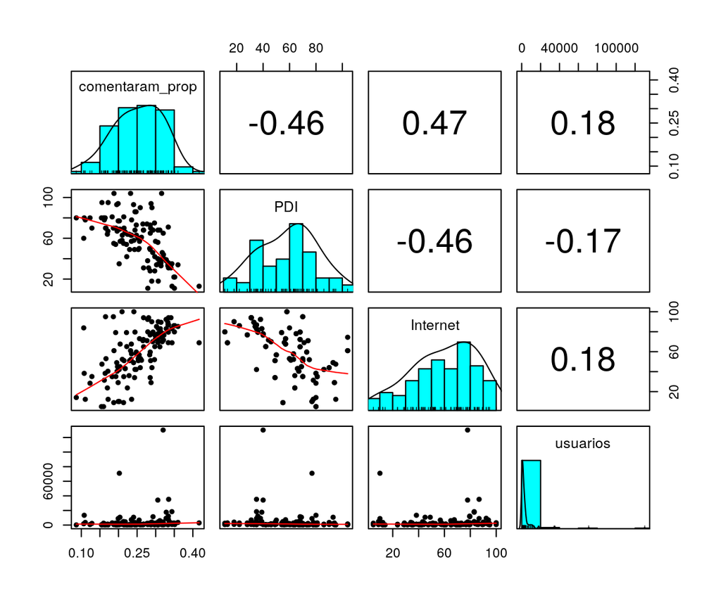

```r
# http://jamesmarquezportfolio.com/correlation_matrices_in_r.html#.WP6WeFB-BPd.facebook
# Para instalar:
# install.packages("${url}", repos=NULL, type="source"

library(psych)

dados %>% select(comentaram_prop,
       PDI, Internet, usuarios) %>% na.exclude() %>% pairs.panels(scale=F, ellipses = F, method = "kendall")
```

Foi escolhida uma visualização de uma matrix de correlações com uma visualzação da distribuição de cada uma das variáveis, de maneira a facilitar o entendimento sobre as relações entre as variáveis e a semelhança de suas distribuições.

## Outras formas de ver

Em seguida, faça 5 visualizações que usem as mesmas variáveis e também pontos, mas que sejam **menos eficazes** que a que você escolheu acima.

### 1

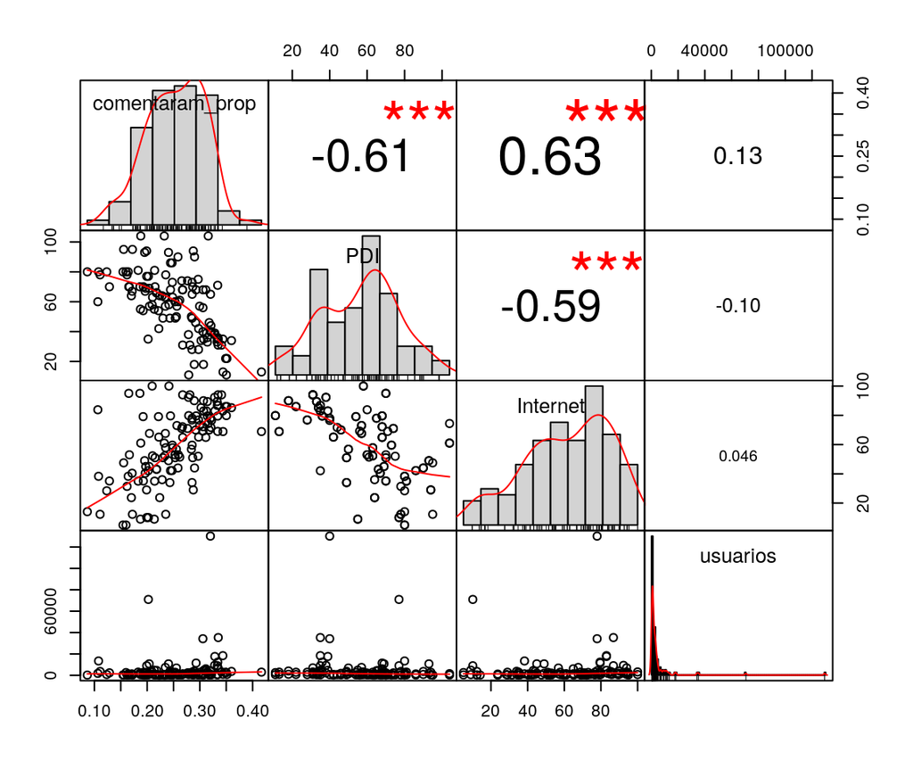

```r
# 1
library("PerformanceAnalytics")

dados %>% select(comentaram_prop,
       PDI, Internet, usuarios) %>% na.exclude() %>% chart.Correlation(histogram=TRUE, pch=19)
```

### 2

A próxima visualização não apresenta os valores de correlação. O leitor tem que estudar apenas os plots com os pontos para estudar a correlação.

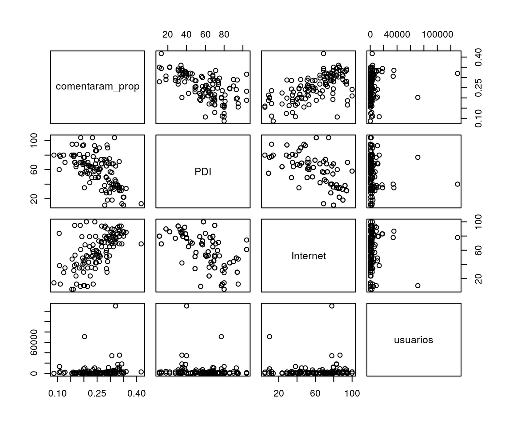

```r
# 2
dados %>% select(comentaram_prop,
       PDI, Internet, usuarios) %>% na.exclude() %>% pairs()
```

### 3

A visualização abaixo é bem parecida com a visualição escolhida inicialmente. Contudo, ao utilizar o tamanho dos números que apresentam as correlações perdemos a legibilidade desses valores.

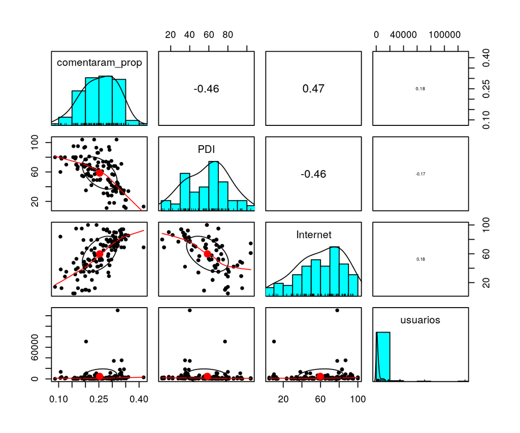

```r
# 3
dados %>% select(comentaram_prop,
       PDI, Internet, usuarios) %>% na.exclude() %>% pairs.panels(scale=T, method = "kendall")
```

### 4

A próxima visualização nos dá uma matrix que mostra apenas os valores das correlações.

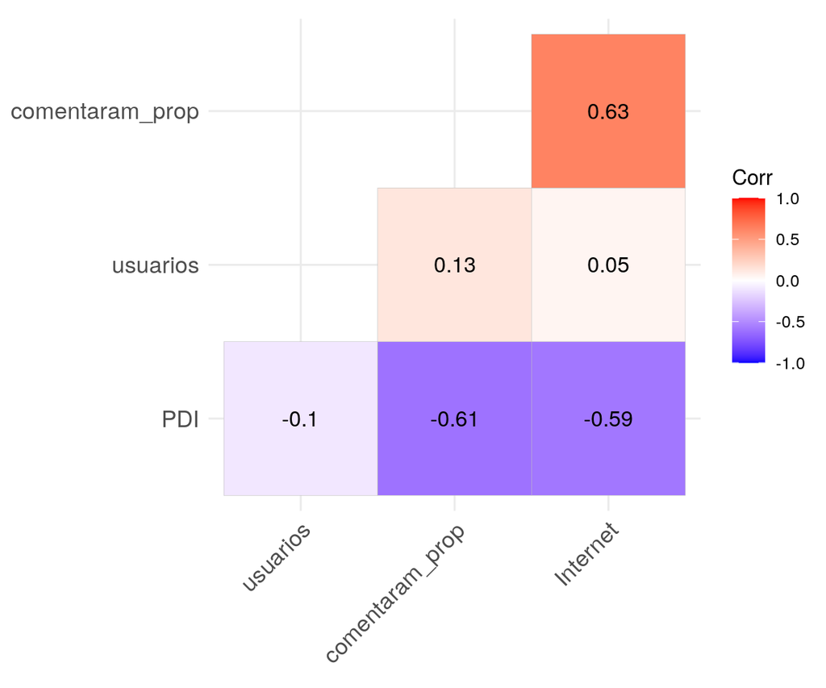

```r
# 4
library(ggcorrplot)

dados %>% select(comentaram_prop,
       PDI, Internet, usuarios) %>% na.exclude() -> novos_dados

ggcorrplot(cor(novos_dados), p.mat = cor_pmat(mtcars), hc.order=TRUE, type='lower', lab = TRUE,)
```

### 5

Já a última visualização é a mais próxima a visualização escolhida. Contudo, não são mostrados os histogramas nem a linha de uma média condicional suavizada. Isso torna a visualização um pouco menos eficaz.

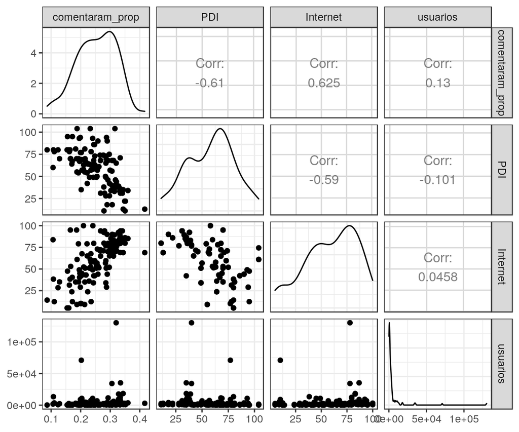

```r
# 5

library(GGally)

dados %>% select(comentaram_prop,
       PDI, Internet, usuarios) %>% na.exclude() %>% ggpairs()
```